# Homework 4

Nikole Vannest, Emiliano Espinoza, Elena Oritz

5/28/2021

1. Create a quadratic damage function relating the `$$` value of damages to the change in global mean temperature and plot with underlyind data.

```r
#damages %>% ggplot(aes(x = warming, y = damages)) + geom_point()
```

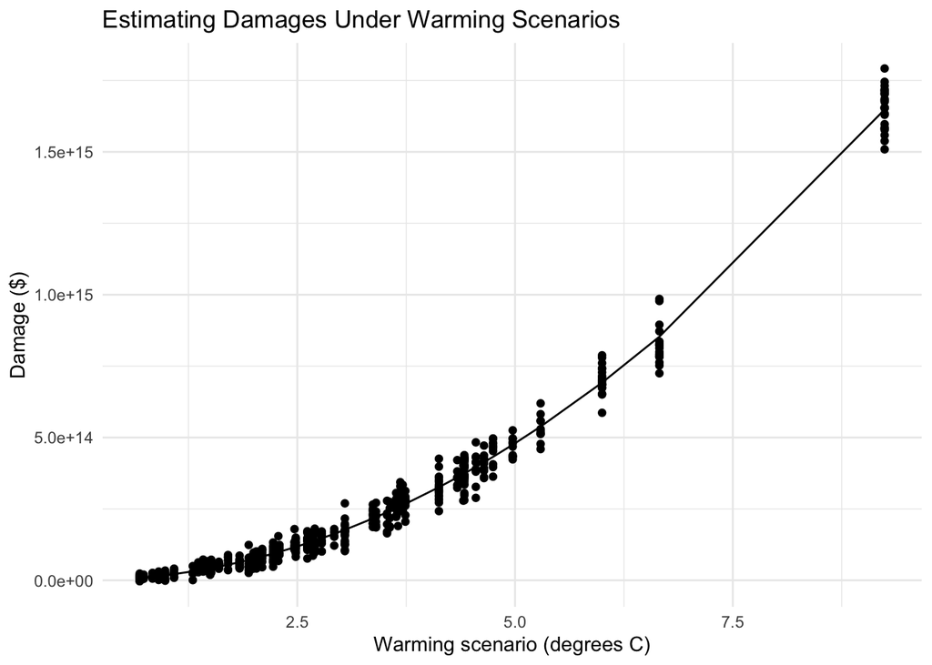

```r
#y = ax^2 + bx + c

damages_quadratic <- cbind("warming_sq" = (damages$warming)^2, damages)
damages_lm <- lm(damages ~ warming_sq + warming + 0, data = damages_quadratic) #linear model
a <- damages_lm$coefficients[["warming_sq"]] #coefficient a
b <- damages_lm$coefficients[["warming"]] #coefficient b

damages_lm2 <- a*damages_quadratic$warming_sq + b*damages_quadratic$warming #Calculating quadratic equation

damages_quadratic %>% ggplot(aes(x = warming, y = damages)) +
  geom_point() +
  geom_line(aes(y = damages_lm2)) +
  ylab("Damage ($)") +
  xlab("Warming scenario (degrees C)") +
  theme_minimal()+
  ggtitle("Estimating Damages Under Warming Scenarios")
```

2. Use warming data to predict damages under baseline and pulse scenarios.

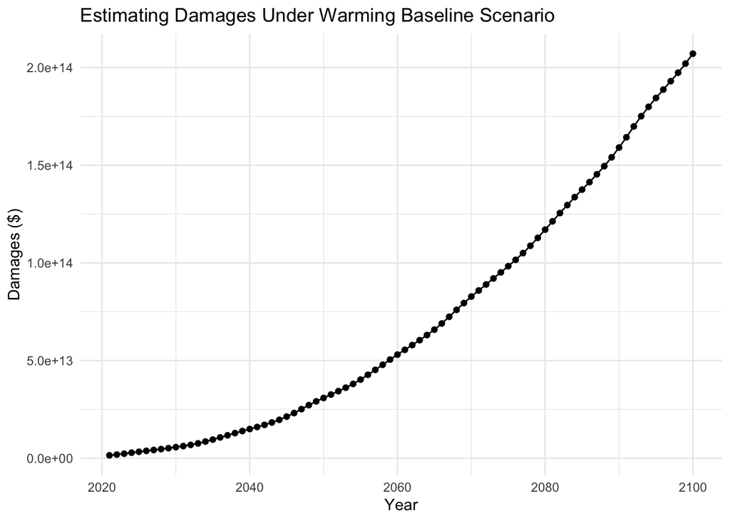

```r
damages_baseline <- a*((warming$warming_baseline)^2) + b*warming$warming_baseline

warming %>% ggplot(aes(x = year, y = damages_baseline)) +
  geom_point() +
  geom_line(aes(y = damages_baseline)) +
  ylab("Damages ($)") +
  xlab("Year") +
  theme_minimal()+
  ggtitle("Estimating Damages Under Warming Baseline Scenario")
```

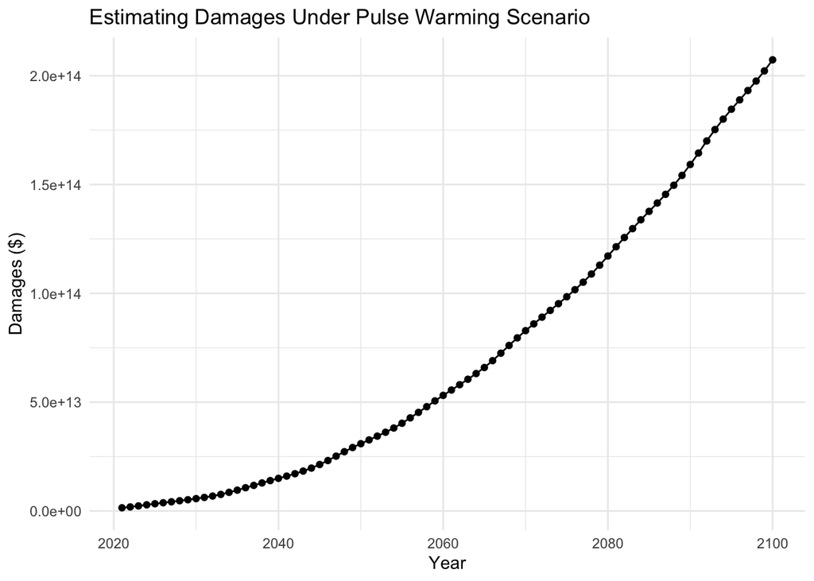

```r
damages_pulse <- a*((warming$warming_pulse)^2) + b*warming$warming_pulse

warming %>% ggplot(aes(x = year, y = damages_pulse)) +
  geom_point() +
  geom_line(aes(y = damages_pulse)) +
  ylab("Damages ($)") +
  xlab("Year") +
  theme_minimal()+
  ggtitle("Estimating Damages Under Pulse Warming Scenario")
```

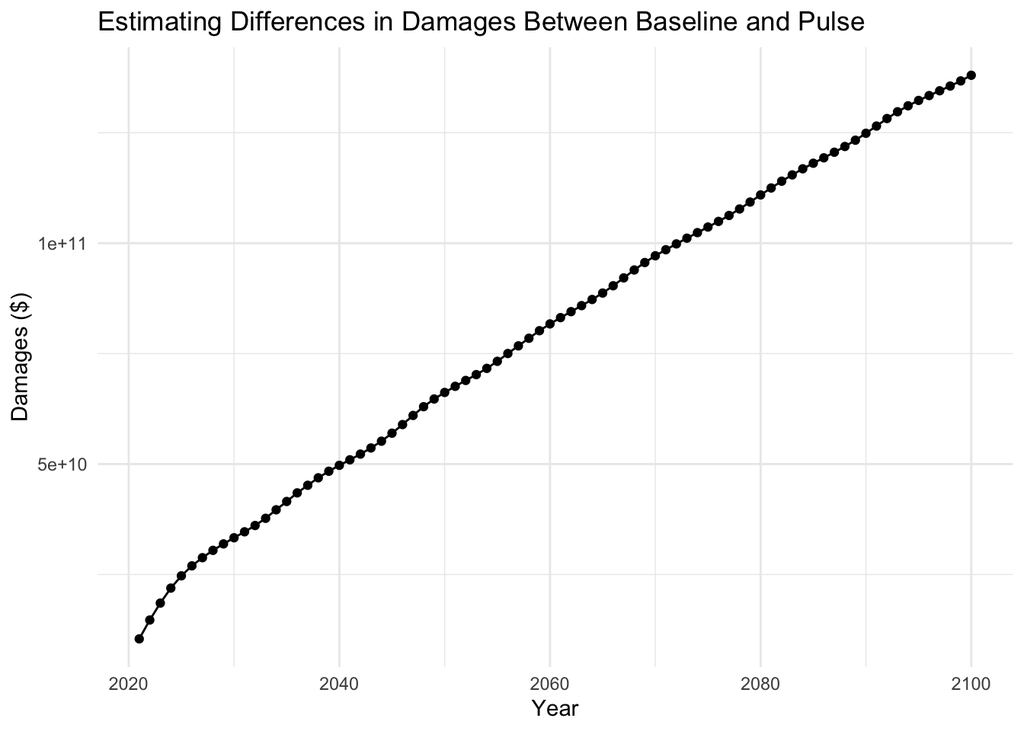

```r
difference_scenario <- damages_pulse - damages_baseline

warming %>% ggplot(aes(x = year, y = difference_scenario)) +
  geom_point() +
  geom_line(aes(y = difference_scenario)) +
  ylab("Damages ($)") +
  xlab("Year") +
  theme_minimal()+
  ggtitle("Estimating Differences in Damages Between Baseline and Pulse")
```

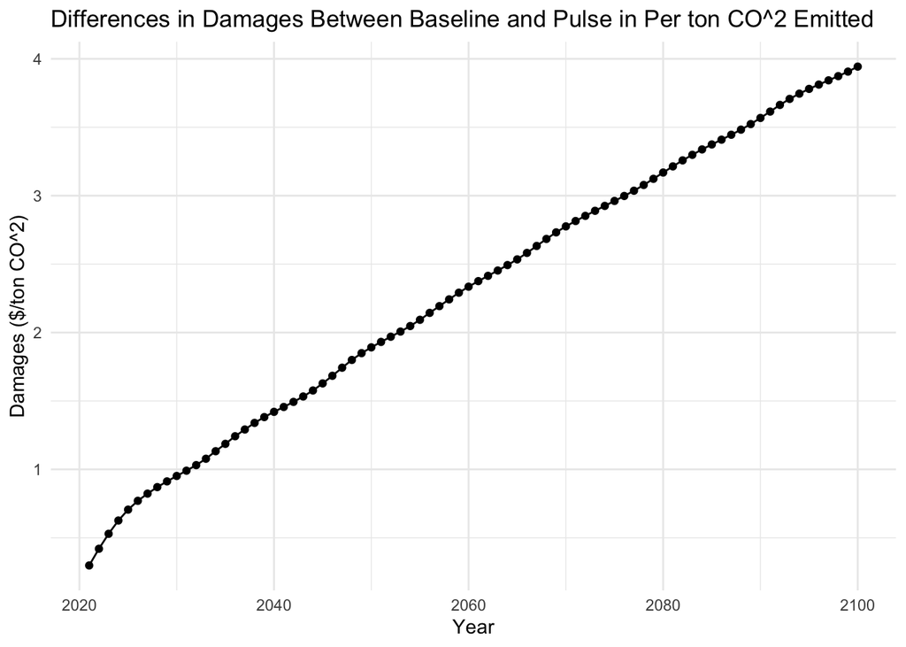

```r
per_ton <- difference_scenario / 35000000000 #to get per ton CO2

warming %>% ggplot(aes(x = year, y = per_ton)) +
  geom_point() +
  geom_line(aes(y = per_ton)) +
  ylab("Damages ($/ton CO^2)") +
  xlab("Year") +
  theme_minimal()+
  ggtitle("Differences in Damages Between Baseline and Pulse in Per ton CO^2 Emitted")
```

3. Calcuate the SCC against the discount rate for a reasonable range of discount rates.
- Obama: 3%
- NY State: 2%

Here we have calculated the SCC at discount rates between 1-5%

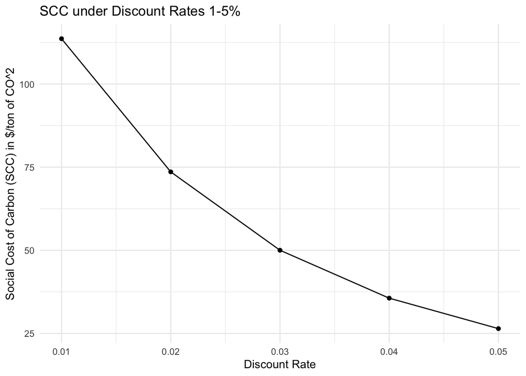

```r
#cost/(1+rate)^year

SCC <- c()
rates <- c(0.01, 0.02, 0.03, 0.04, 0.05) #Discount rates chosen
for(i in 1:length(rates)) { #Calculating PV's in the loop
  temp <- (per_ton)/(1+rates[i])^(warming$X)
  SCC[i] <- sum(temp)
}

SCC_table <- round(data.frame("rates" = rates, #put into a data frame to run in ggplot
                        "SCC" = SCC), 2)

SCC_table %>% ggplot(aes(x = rates)) + #create a graph of SCC's under discount rates
  geom_point(aes(y = SCC)) +
  geom_line(aes(y = SCC)) +
  theme_minimal() +
  xlab("Discount Rate") +
  ylab("Social Cost of Carbon (SCC) in $/ton of CO^2") +
  ggtitle("SCC under Discount Rates 1-5%")
```

- SCC at 1%: $113.64/ton CO^2
- SCC at 2%: $73.59/ton CO^2
- SCC at 3%: $50.02/ton CO^2
- SCC at 4%: $35.61/ton CO^2
- SCC at 5%: $26.45/ton CO^2

4.What is the SCC using the Ramsey Rule?

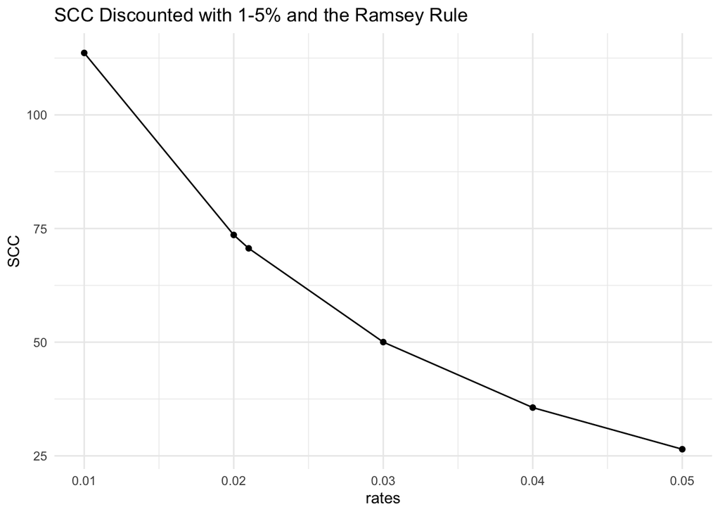

```r
#r = p +ng

p <- 0.001
n <- 2
g <- 0.01

ramsey <- p + n*g #Ramsey Rule equation

SCC_ramsey <- c()
rates_ramsey <- c(0.01, 0.02, 0.03, 0.04, 0.05, ramsey) #Adding Ramsey to the loop
for(i in 1:length(rates_ramsey)) {
  temp <- (per_ton)/(1+rates_ramsey[i])^(warming$X)
  SCC_ramsey[i] <- sum(temp)
}

ramsey_table <- data.frame("rates" = rates_ramsey, #Moving to a data frame for ggplot
                           "SCC" = SCC_ramsey)

ramsey_table %>% ggplot(aes(x = rates)) + #Graphing the SCC's under several discount rates
  geom_point(aes(y = SCC)) +
  geom_line(aes(y = SCC)) +
  theme_minimal() +
  ggtitle("SCC Discounted with 1-5% and the Ramsey Rule")
```

The point calculated using the Ramsey Rule is located at location (`x = 0.021`,`y = 70.65`).

**5. What are the expected damages up to year 2100 under Policy A and Policy B?**

**Facts**

- **Policy A**: Either baseline (probability 0.5) or warming each year will be 1.5 times that of the baseline (probability 0.5)
- **Policy B**: Continue until 2050 at baseline, then stay at 1.29 degrees warming forever
- Society is risk neutral
- Discount rate = 2%

```r
#(Scenario 1 * probability) + (Scenario 2 * probability)
warming_1.5 <- warming$warming_baseline * 1.5 #create warming scenario
damages_1.5 <- a*((warming_1.5)^2) + b*warming_1.5 #plug into quadratic equation

policy_a <- (damages_baseline*0.5) + (damages_1.5*0.5) #calculate overall expected damages

policy_a_discount <- (policy_a)/(1+0.02)^(warming$X) #calculate present value for each year
policy_a_pv <- sum(policy_a_discount) #Sum for NPV

b_1.29 <- rep(1.29, 50) #Create warming sequence for scenario b
policy_b_warming <- c(warming$warming_baseline[1:30], b_1.29) #combine with baseline
damages_b <- a*((policy_b_warming)^2) + b*policy_b_warming #put into quadratic equation
policy_b <- (damages_b)/(1+0.02)^(warming$X) #calculate present value
policy_b_pv <- sum(policy_b) #find NPV

difference_ab <- policy_a_pv-policy_b_pv #Value of X to meet damages in policy A

baseline_0.02 <- (damages_baseline)/(1+0.02)^(warming$X)
baseline_sum <- sum(baseline_0.02) #Calculate sum of PV of baseline scenario alone

warm_1.5_0.02 <- (damages_1.5)/(1+0.02)^(warming$X) #Calculate sum of PV of 1.5 warming scenario alone
warm1.5_sum <- sum(warm_1.5_0.02)
```